# Languages

Chizurum Agomoh

2023-03-30

# About Dataset

## Context

Note that it is difficult to say what makes a language a langauge as opposed to a dialect. Chinese and Arabic are often categorized as individual languages, however, they each consist of multiple distinct varieties that are mutually unintelligible. Due to these differences between the varieties, some linguists consider these languages to be better viewed as a collection of related dialects or language families, rather than a single language. These language families also have different branches under them.

## Content

In this Dataset we have the complete list of the Most Spoken Languages in the World (in millions)

## Head of Dataset

```
##                                                              Language
## 1                                     English(excl. creole languages)
## 2 Mandarin Chinese(incl. Standard Chinese, but excl. other varieties)
## 3                                                   Hindi(excl. Urdu)
## 4                                                             Spanish
## 5                                                              French
## 6                              Modern Standard Arabic(excl. dialects)
##          Family     Branch First.language.L1..speakers
## 1 Indo-European   Germanic               372.9 million
## 2  Sino-Tibetan    Sinitic               929.0 million
## 3 Indo-European Indo-Aryan               343.9 million
## 4 Indo-European    Romance               474.7 million
## 5 Indo-European    Romance                79.9 million
## 6  Afro-Asiatic    Semitic                        0[a]
##   Second.language.L2..speakers Total.speakers.L1.L2.
## 1              1080 million[5]          1452 million
## 2             198.7 million[6]          1118 million
## 3             258.3 million[7]         602.2 million
## 4              73.6 million[8]         548.3 million
## 5             194.2 million[9]         274.1 million
## 6            274.0 million[11]         274.0 million
```

## Summary of Dataset

```
##    Language            Family             Branch
##  Length:45          Length:45          Length:45
##  Class :character   Class :character   Class :character
##  Mode  :character   Mode  :character   Mode  :character
##  First.language.L1..speakers Second.language.L2..speakers Total.speakers.L1.L2.
##  Length:45                   Length:45                    Length:45
##  Class :character            Class :character             Class :character
##  Mode  :character            Mode  :character             Mode  :character
```

## Column names

```
## [1] "Language"                     "Family"
## [3] "Branch"                       "First.language.L1..speakers"
## [5] "Second.language.L2..speakers" "Total.speakers.L1.L2."
```

## Cleaned Dataset

```
##                                                              Language
## 1                                     English(excl. creole languages)
## 2 Mandarin Chinese(incl. Standard Chinese, but excl. other varieties)
## 3                                                   Hindi(excl. Urdu)
## 4                                                             Spanish
## 5                                                              French
## 6                              Modern Standard Arabic(excl. dialects)
##          Family     Branch First.language.L1..speakers
## 1 Indo-European   Germanic                   372900000
## 2  Sino-Tibetan    Sinitic                   929000000
## 3 Indo-European Indo-Aryan                   343900000
## 4 Indo-European    Romance                   474700000
## 5 Indo-European    Romance                    79900000
## 6  Afro-Asiatic    Semitic                           0
##   Second.language.L2..speakers Total.speakers.L1.L2.
## 1                    1.080e+09             1.452e+09
## 2                    1.987e+08             1.118e+09
## 3                    2.583e+08             6.022e+08
## 4                    7.360e+07             5.483e+08
## 5                    1.942e+08             2.741e+08
## 6                    2.740e+08             2.740e+08
```

# Top 10 Languages Worldwide (Based on total number of speakers)

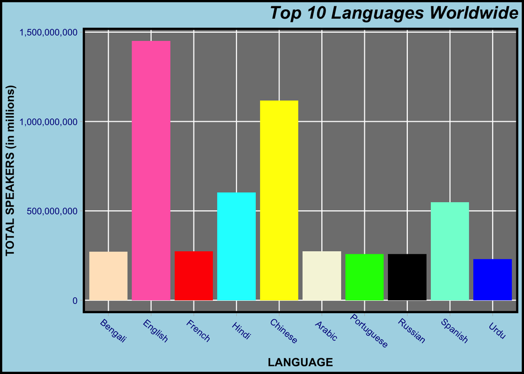

Figure 1: Top 10 Languages Worldwide

This bar graph shows us the top 10 most spoken languages worldwide. Based on this visualization we can see that English is the most popular language in the globally, with almost 1.5 billion speakers. This graph also shows that Chinese is the second most spoken language followed by Hindi.

# Most Popular Language Families

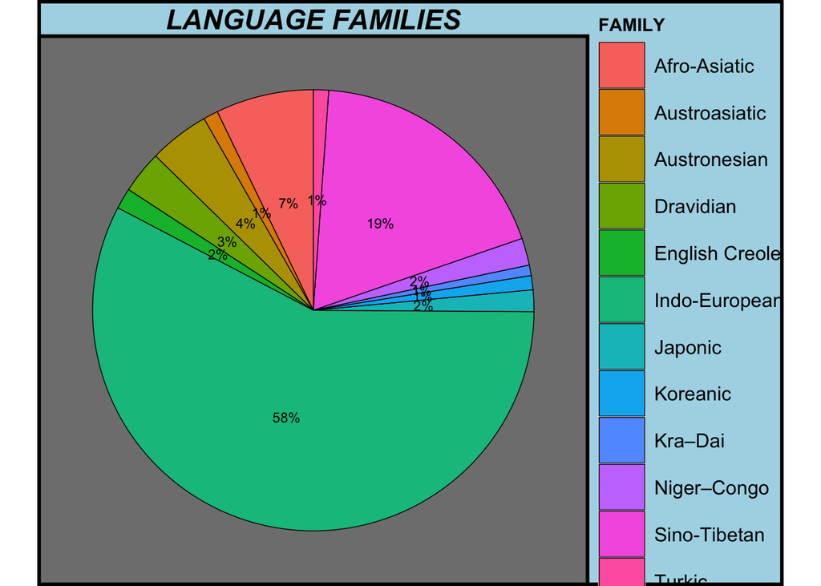

Figure 2: Language Families

This graphic shows the relative sizes of different language families in the world. From observation of the figure, we can see that the Indo-European language family is the most prominent in the world, with English being one of its largest and most widely spoken members. English creole is not a language family, but rather a group of creole languages based on English, which incorporate vocabulary and grammatical structures from African, Caribbean, and other languages. The second most prominent language family shown by the graphic is Sino-Tibetan, which includes many languages spoken in East Asia, Southeast Asia, and South Asia.

# Map Of Indo-European Speaking Countries

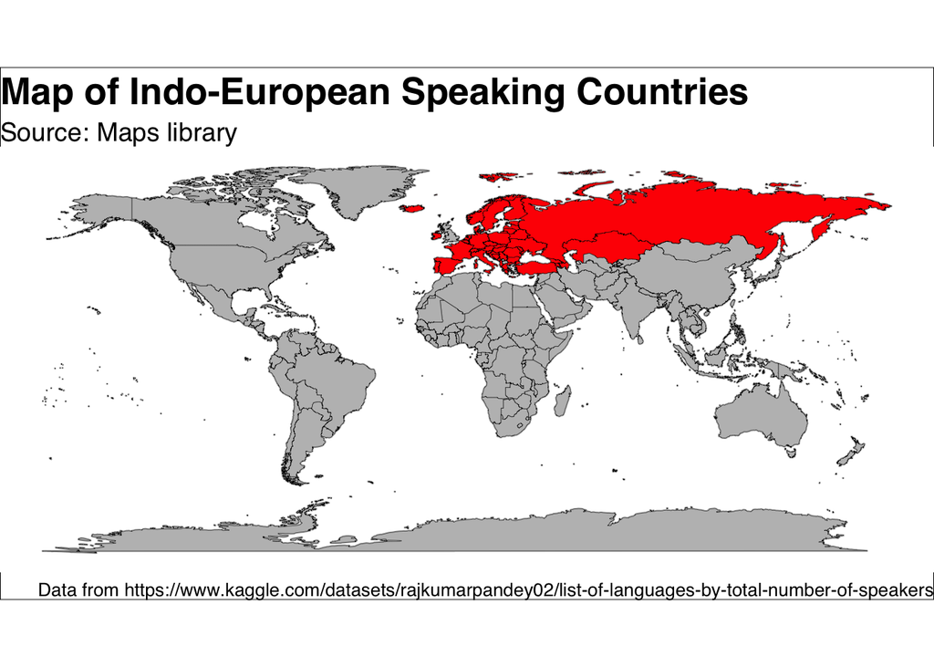

Figure 3: Map of Indo-European speaking Countries

The map output above shows a map of the world where countries that are part of the Indo-European language family are highlighted in red, while the other countries are in gray.

# References

United Nations, Department of Economic and Social Affairs, Population Division (2019). World Population Prospects 2019, Online Edition. Rev. 1. Retrieved from https://population.un.org/wpp/

Wikipedia contributors. (2022, March 14). List of languages by total number of speakers. In Wikipedia, The Free Encyclopedia. Retrieved 06:40, April 2, 2023, from https://en.wikipedia.org/w/index.php?title=List_of_languages_by_total_number_of_speakers&oldid=1119330648

World Atlas. (2022). The Most Spoken Languages in the World. Retrieved from https://www.worldatlas.com/articles/the-most-spoken-languages-in-the-world.html